# Colimits of sets and C-sets

Compositional Methods for Health Modeling

[figure not shown]

Evan Patterson  
AlgebraicJulia

August 3, 2022

# Objects and morphisms

Category theory as mathematical structuralism:

- it’s not about mathematical objects in isolation
- but about how different objects *relate* to each other.

This viewpoint is also relevant to science:

- scientists understand the *objects* of their domain (models, data, etc)
- but usually don’t formalize the *relations* between them.

Applied category theory can help here!

## Illustration: categories of sets

| Category | Objects | Morphisms |
| --- | --- | --- |
| $\Set$ | sets | functions |
| $\CAT{Bij}$ | sets | bijections |
| $\CAT{Par}$ | sets | partial functions |
| $\CAT{Rel}$ | sets | relations |
| $\CAT{Corel}$ | sets | corelations<sup>1</sup> |

- All these categories have sets as objects, but different morphisms
- They behave very differently!
[^1]: Fong & Spivak, 2021: *Seven sketches in compositionality*, Example 4.46

## Universal constructions in a category

Once you have a category—objects *and* morphisms—you can ask about:

- limits: products, pullbacks, etc
- colimits: coproducts, pushouts, etc
- exponentials
- dependent sums & products
- …

Such universal constructions

- do not always exist in a given category
- but when they do, there are *unique* (up to isomorphism)
- so we can get powerful tools for *“for free”*

## Plan

Last time, we introduced $\cat{C}$-sets as objects.

This time, we introduce $\catSet{C}$, the category of $\cat{C}$-sets:

- homomorphisms of $\cat{C}$-sets
- finding $\cat{C}$-set homomorphisms using Catlab

We then study two important universal constructions, in $\Set$ and $\catSet{C}$:

1. coproducts
2. pushouts

# Categories of $\cat{C}$-sets

The three fundamental concepts of CT are:

1. *categories*
2. *functors*: morphisms of categories
3. *natural transformations*: morphisms of functors

We’ve seen (1) and (2). We now see (3) in the case of set-valued functors.

## First example: morphisms of DDS

Recall that a discrete dynamical system (DDS) is a $\cat{C}$-set for

$$\cat{C} = \left\langle \stackrel{\curvearrowleft s}{\bullet} \right\rangle
= \{1, s, s^2, s^3, \dots\}.$$

**Definition**: A morphism of DDS $X \to Y$ is a function $f: X(\bullet) \to Y(\bullet)$ such that the square commutes:

$$\require{AMScd}
\begin{CD}
X(\bullet) @>{X(s)}>> X(\bullet) \\
@V{f}VV @VV{f}V \\
Y(\bullet) @>>{Y(s)}> Y(\bullet)
\end{CD}$$

Such a function $f$ is also called an intertwining of $X$ and $Y$.

## First example: morphisms of DDS

#### Dynamical interpretation

1. Choose any $x_0 \in X(\bullet)$
2. Put $y_0 := f(x_0) \in Y(\bullet)$
3. For all $n \in \N$, put
   $$x_{n+1} := X(s)(x_n), \qquad y_{n+1} := Y(s)(y_n).$$

**Proposition**

If the function $f: X(\bullet) \to Y(\bullet)$ is a DDS homomorphism, then

$$y_n = f(x_n) \qquad\text{for all $n \in \N$}.$$

Proof is by induction on $n$.

## $\cat{C}$-set homomorphisms

Let $\cat{C}$ be a small category and $X,Y$ be $\cat{C}$-sets.

**Definition**: A $\cat{C}$-set homomorphism $\alpha: X \to Y$ consists of:

- for every object $c \in \cat{C}$, a function $\alpha_c: X(c) \to Y(c)$
- such that for every $f: c \to d$ in $\cat{C}$, the naturality square commutes:

$$\require{AMScd}
\begin{CD}
X(c) @>{X(f)}>> X(d) \\
@V{\alpha_c}VV @VV{\alpha_d}V \\
Y(c) @>>{Y(f)}> Y(d)
\end{CD}$$

## $\cat{C}$-set homomorphisms

Restating the previous slide:

**Definition**: A $\cat{C}$-set homomorphism from $X$ to $Y$ is a natural transformation

[figure not shown]

The general definition of a natural transformation is nearly the same, replacing $\Set$ with an arbitrary category.

## Example: Graph homomorphisms

Recall that a graph is a $\cat{C}$-set for $\cat{C} = \displaystyle\left\langle E \mathop{\rightrightarrows}^s_t V \right\rangle$.

A graph homomorphism $\phi: G \to H$ consists of vertex and edge maps

$$\phi_V: G(V) \to H(V), \qquad
\phi_E: G(E) \to H(E)$$

that preserve the edge sources and targets:

$$\require{AMScd}
\begin{CD}
G(E) @>{G(s)}>> G(V) \\
@V{\phi_E}VV @VV{\phi_V}V \\
H(E) @>>{H(s)}> H(V)
\end{CD}
\qquad
\begin{CD}
G(E) @>{G(t)}>> G(V) \\
@V{\phi_E}VV @VV{\phi_V}V \\
H(E) @>>{H(t)}> H(V)
\end{CD}$$

## Example: Graph colorings as homomorphisms

- An $n$-coloring of a graph or symmetric graph is a homomorphism into the complete graph $K_n$
- Catlab can find $\cat{C}$-set morphisms using the function [`homomorphisms`](https://algebraicjulia.github.io/Catlab.jl/v0.14/apis/categorical_algebra/#Catlab.CategoricalAlgebra.CSets.homomorphism-Tuple%7BACSet,%20ACSet%7D)
- Code below shows that the wheel graph $W_7$
  - is not 2-colorable
  - has $3 \cdot 2 = 6$ different 3-colorings

```julia
using Catlab.Graphs, Catlab.Graphics

W₇ = wheel_graph(SymmetricGraph, 7)
to_graphviz(W₇)
```

[figure not shown]

```julia
using Catlab.CategoricalAlgebra

K₂ = complete_graph(SymmetricGraph, 2)
length(homomorphisms(W₇, K₂))
```

```
0
```

```julia
K₃ = complete_graph(SymmetricGraph, 3)
length(homomorphisms(W₇, K₃))
```

```
6
```

# Coproducts

Coproducts are our first example of a universal construction:

- a type of colimit
- relatively simple, but important
- an abstraction of disjoint unions of sets

## Coproducts: universal property

**Definition**: A category $\cat{C}$ has binary coproducts if we can choose

- for every pair of objects $x$ and $y$, an object $x+y$
- such that morphisms out of $x+y$ in natural bijection with *pairs* of morphisms out of $x$ and $y$:
  $$\begin{aligned}
  \Hom_{\cat{C}}(x+y, z) &\cong \Hom_{\cat{C}}(x,z) \times \Hom_{\cat{C}}(y,z) \\
  x+y \xrightarrow{h} z \quad &\leftrightarrow \quad
  \big(x \xrightarrow{f} z,\ y \xrightarrow{g} z\big)
  \end{aligned}$$

This universal property characterizes coproducts up to isomorphism.

## Coproducts of sets

In $\Set$, coproducts are given by disjoint union, aka tagged union:

$$X + Y = X \sqcup Y := \{(1,x): x \in X\} \cup \{(2,y): y \in Y\}.$$

The universal property

$$X + Y \xrightarrow{h} Z \qquad\leftrightarrow\qquad
\big(X \xrightarrow{f} Z,\ Y \xrightarrow{g} Z).$$

is satisfied using “definition by cases”:

$$h(i,w) = \begin{cases}
f(w) &\text{if $i=1$} \\
g(w) &\text{if $i=2$}.
\end{cases}$$

The names of the tags, $1$ and $2$, are arbitrary. All that matters is that the universal property is satisfied!

## Coproducts, equationally

Apply the universal property to the identity on $x+y$:

$$x+y \xrightarrow{1_{x+y}} x+y \qquad\leftrightarrow\qquad
\big(x \xrightarrow{\iota_x} x+y,\ y \xrightarrow{\iota_y} x+y)$$

**Equivalent definition**: A coproduct of objects $x$ and $y$ in a category $\cat{C}$ is

- an object $x+y \in \cat{C}$
- equipped with maps $\iota_x: x \to x+y$ and $\iota_y: y \to x+y$, called coprojections or inclusions
- and an operation called copairing
  $$(f: x \to z,\ g: y \to z) \mapsto [f,g]: x+y \to z$$
- subject to a few equations (omitted).

## Coproducts of $\cat{C}$-sets

Coproducts in $\catSet{C}$ are computed “pointwise” in $\Set$:

$$\begin{aligned}
(X+Y)(c) &= X(c) + Y(c) && c \text{ in } \cat{C} \\
(X+Y)(f) &= [X(f) \cdot \iota_{X(d)}, Y(f) \cdot \iota_{Y(d)}]
&& f: c \to d \text{ in } \cat{C}
\end{aligned}$$

**Example: Coproduct of graphs**

The coproduct $G+H$ of graphs $G$ and $H$ has vertex and edge sets

$$(G+H)(V) = G(V)+H(V), \qquad (G+H)(E) = G(E)+H(E).$$

## Coproducts in Catlab

In Catlab, coproducts are accessed through their equational description.

Create graphs $G_1$ and $G_2$:

```julia
g₁ = path_graph(Graph, 3)

to_graphviz(g₁)
```

[figure not shown]

```julia
g₂ = cycle_graph(Graph, 4)

to_graphviz(g₂)
```

[figure not shown]

Form coproduct $G = G_1 + G_2$:

```julia
colim = coproduct(g₁, g₂)::Coproduct{Graph}
g = ob(colim)::Graph

to_graphviz(g)
```

[figure not shown]

Coprojections and copairing:

```julia
ι₁ = coproj1(colim)
ι₂ = coproj2(colim)
copair(ι₁, ι₂) == force(id(g))
```

```
true
```

# Pushouts

Pushouts are another universal construction:

- a type of colimit
- a generalization of coproducts
- an abstraction of gluing/quotients of sets

## Pushouts: intuitions

The pushout of a span of maps

$$X \xleftarrow{f} Z \xrightarrow{g} Y$$

is the object $X +_Z Y$ obtained by “gluing” $X$ and $Y$ together along $Z$.

**Pushouts of topological spaces**

In $\CAT{Top}$, the pushout of the span of continuous maps $X \hookleftarrow A \xrightarrow{f} Y$ is an “attaching space”:

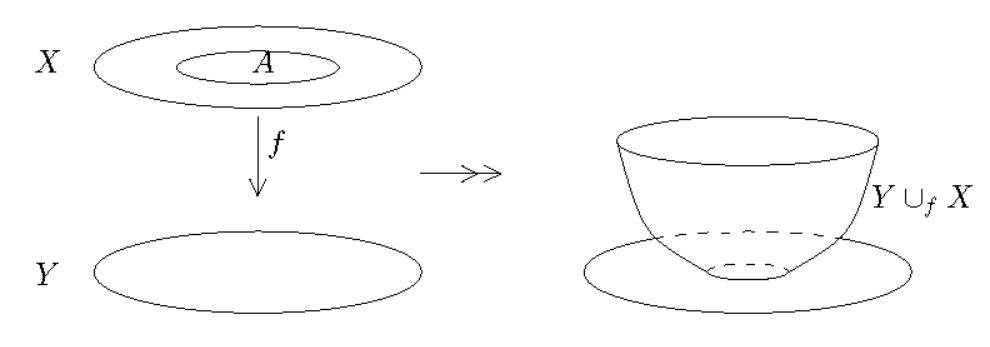

Image source: [nLab: space attachment](https://ncatlab.org/nlab/show/space+attachment)

## Pushouts, abstractly

The pushout of a span $x \xleftarrow{f} z \xrightarrow{g} y$ in a category $\cat{C}$ is a commutative square

[figure not shown]

in $\cat{C}$ satisfying a *universal property* among all such squares (omitted).

- Commutativity ($f \cdot \iota_x = g \cdot \iota_y$) means $x$ and $y$ are glued along $z$
- Universal property means gluing is *only* along $z$

## Pushouts of sets and $\cat{C}$-sets

In $\Set$, pushouts are given by quotients of the disjoint union:

$$X +_Z Y = (X+Y)/\sim$$

where $\sim$ is the equivalence relation generated by

$$(1,f(z)) \sim (2,g(z)), \qquad z \in Z.$$

In $\catSet{C}$, pushouts are computed pointwise:

$$(X +_Z Y)(c) = X(c) +_{Z(c)} Y(c), \qquad c \in \cat{C}.$$

In general, limits and colimits in $\catSet{C}$ are computed pointwise in $\Set$.

## Pushouts in Catlab

Pushouts & coproducts share interface: `ob`, `coproj1`, `coproj2`, `copair`.

```julia
C₆ = cycle_graph(SymmetricGraph, 6)

to_graphviz(C₆)
```

[figure not shown]

```julia
I = path_graph(SymmetricGraph, 2)

to_graphviz(I)
```

[figure not shown]

```julia
ϕ = homomorphism(I, C₆,
                 initial=(E=Dict(1 => 1),))
components(ϕ)
```

```
(V = FinFunction([1, 2], 2, 6), E = FinFunction([1, 7], 2, 12))
```

```julia
colim = pushout(ϕ, ϕ)

to_graphviz(ob(colim))
```

[figure not shown]

[figure not shown]